# 07 · Q4 Pulse 3: draft codebooks for participants’ first messages

What people first asked an AI about their health (topic), and what kind of help they wanted (type of request)

Denicia Aragon Espinosa

November 05, 2026

## In short

- **What changed.** We now code only each participant’s **first message** to the AI, which is what they asked about before the AI’s answers steered the conversation. This means no code can be about “replying to the AI”.
- **Two separate codebooks.**
  1. **Health topic:** *what* the message is about, such as a condition, a body system or an area of health. Each message gets one main (**primary**) topic and, if needed, one **secondary** topic.
  2. **Type of request:** *what kind of help* the person wanted from the AI. One message can ask for more than one kind of help.
- **How.** For each codebook, an LLM (Claude Opus 5.5, the model running this coding session) read all 53 first messages **3 separate times**. Each time it used a different random order and had no memory of the other passes. A 4th fresh session merged the three lists, keeping only codes found in **at least 2 of the 3 passes**.
- **Exclusions.** 1 chat (69c41892) was excluded *after* the passes: it was a pasted homework assignment, not a personal health conversation. The passes saw it, but it is left out of every count, kappa and example below, so the results describe **52 first messages** (section 4).
- **Your review decisions.** After reading the draft you made documented changes: “Help with a text task” was dropped, a **Mental health and stress** topic was added, and 3 messages were recoded (section 4). After the pilot you also decided that **type of request is the main analysis** and **health topics are a simple descriptive list**. The LLM passes were not rerun.
- **The first *real* message.** In 3 chats the first message was only a greeting, a joke or a one-word reply (“Hi meta”, “nope”). For these we code the person’s **next message that asks or says something about health** instead. Three fresh coders coded these messages with the frozen codebook, and all three agreed every time (section 4, “The first real message rule”).
- **Main result: type of request.** The most common requests were *Why is this happening to me?* (29% of first messages) and *General facts about health* (29%). 6 types in all; median kappa per type across the 3 passes = 0.92.
- **Context: health topics.** The most common subject was *Bones, joints and muscles* (9 of 52 messages). The topics are spread across 11 areas, each covering only a few messages.
- **Small codes.** T11 Mental health and stress (2 chats; kept because you asked for it).
- **Quote check.** 199 of 199 example quotes were found word for word in the participant’s first message.
- **Pilot edits applied and codebooks frozen.** You approved the pilot’s request edits E6, E7 and E9. They changed the *wording* of R3, R5 and R6. You first approved E8 too (emotional questions under R1 and R3), then **reverted it**: emotion will be studied later in a sentiment analysis, so it is not part of any request type. The *Mental health and stress* topic stays. Finally, you **renamed R3 and R6 around “problem or goal?”**: R3 is now **“How do I handle this problem, or is it safe?”** and R6 is **“Help me reach a health goal”**. These wording changes did not change any message’s label, so apart from the 3 first-real-message chats the counts here are still the draft counts. Both codebooks are now **frozen** (locked), with the first real message rule written into them, in `output/09_freeze-codebook/frozen_2026-11-05_v4/`. The next step is to code every first message 3 times with them (section 9).

Every prompt, input file and raw LLM output is saved in `output/07_build-codebook/`, so each step can be checked.

## Main result: what people asked the AI for

**Why type of request is the main lens.** The health subjects were very spread out: 11 different areas, most with only 2 to 6 messages each. With 52 messages, a list that thin says little on its own. The *type of request*, in contrast, groups everyone into a few kinds of help, and it answers the question we care most about: **what did people want from the AI?** So type of request is the main analysis, with the full reliability checks: 3 independent passes, kappa, and the pilot in step 08. Health topics are kept as **context**: a simple list of what the messages were about.

The chart shows the share of the 52 first messages asking for each kind of help. **One message can ask for more than one kind of help**, so the percentages add up to more than 100%.

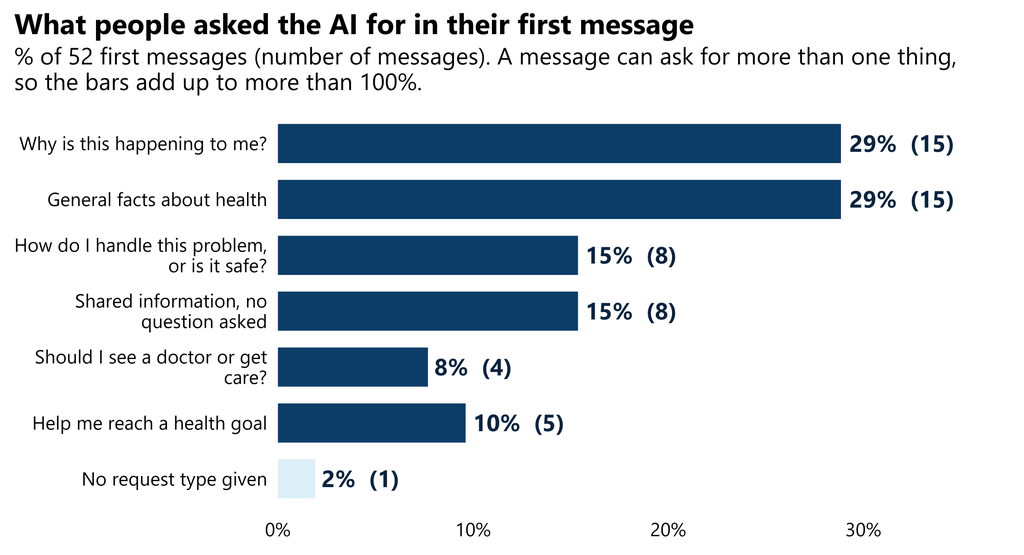

```r
req_main <- main_request |>
  mutate(is_none = code == "NONE",
         label = factor(plain_label, levels = rev(plain_label)))
p_main <- ggplot(req_main, aes(pct_messages, label, fill = is_none)) +
  geom_col(width = 0.7) +
  geom_text(aes(label = paste0(pct(pct_messages), "  (", n_messages, ")")),
            hjust = -0.08, size = 7, fontface = "bold", color = project_colors[["charcoal"]]) +
  scale_fill_manual(values = c(`FALSE` = project_colors[["teal"]], `TRUE` = project_colors[["sand"]]), guide = "none") +
  scale_x_continuous(labels = scales::percent, limits = c(0, max(req_main$pct_messages) * 1.3),
                     expand = expansion(mult = c(0, 0))) +
  scale_y_discrete(labels = function(x) str_wrap(x, 30)) +
  labs(title = "What people asked the AI for in their first message",
       subtitle = paste0("% of ", n_analysed, " first messages (number of messages). ",
                         "A message can ask for more than one thing,\nso the bars add up to more than 100%."),
       x = NULL, y = NULL)
p_main
```

```r
save_fig("main-request-types", p_main, width = 12, height = 6.5)
```

```r
main_request |>
  transmute(plain_label, code_name = if_else(code == "NONE", "—", paste0(code, " ", name)),
            n_messages, pct_messages) |>
  gt() |>
  cols_label(plain_label = "Kind of help (in plain words)", code_name = "Code in the codebook",
             n_messages = "Messages", pct_messages = paste0("% of ", n_analysed)) |>
  fmt_percent(pct_messages, decimals = 0) |>
  tab_source_note("A message can have more than one type, so the % add up to more than 100%.") |>
  tab_options(table.font.size = px(18), data_row.padding = px(8))
```

| Kind of help (in plain words) | Code in the codebook | Messages | % of 52 |
| --- | --- | --- | --- |
| Why is this happening to me? | R1 Ask what is causing symptoms | 15 | 29% |
| General facts about health | R2 General health facts | 15 | 29% |
| How do I handle this problem, or is it safe? | R3 How do I handle this problem, or is it safe? | 8 | 15% |
| Shared information, no question asked | R4 Information shared without a question | 8 | 15% |
| Should I see a doctor or get care? | R5 Whether to seek medical care | 4 | 8% |
| Help me reach a health goal | R6 Help me reach a health goal | 5 | 10% |
| No request type given | — | 1 | 2% |

A message can have more than one type, so the % add up to more than 100%.

The full definitions are in section 8, and how well the 3 passes agreed on each type is in section 6.

## Context: health topics

This is a **simple descriptive list**: each message is counted **once**, under its main (primary) topic. Secondary topics are left out here; they are still in the codebook and the workbook. Because topics are context only, their agreement statistics are in the appendix, not in the main text.

Messages with no topic in the codebook are listed by what they were about. Each of these groups has only 1 message, so they are shown together as **Other health subject**: *chest pain when running*, a *kidney ultrasound report* (kidney, liver and blood), and a question about *heart and chest scan results*. Since the first real message rule, every analysed message has a health subject, so there is no “No health subject” line.

```r
tl <- topic_list |>
  mutate(kind = case_when(topic %in% c("Other health subject", "No health subject") ~ "other", TRUE ~ "topic"),
         label = factor(topic, levels = rev(topic)))
p_tl <- ggplot(tl, aes(n_messages, label, fill = kind)) +
  geom_col(width = 0.7) +
  geom_text(aes(label = paste0(n_messages, "  (", pct(pct_messages), ")")),
            hjust = -0.1, size = 6.5, fontface = "bold", color = project_colors[["charcoal"]]) +
  scale_fill_manual(values = c(topic = project_colors[["olive"]], other = project_colors[["sand"]]), guide = "none") +
  scale_x_continuous(limits = c(0, max(tl$n_messages) * 1.3), breaks = scales::breaks_pretty(),
                     expand = expansion(mult = c(0, 0))) +
  labs(title = "What the first messages were about",
       subtitle = paste0("Main topic of each of the ", n_analysed, " first messages (one per message)"),
       x = "Messages", y = NULL)
p_tl
```

[figure not shown]

```r
save_fig("topic-list", p_tl, width = 12, height = 8)
```

```r
topic_list |>
  transmute(topic, n_messages, pct_messages,
            note = case_when(topic == "Other health subject" ~ paste0(grouped_from, " (", chat_ids, ")"),
                             topic == "No health subject" ~ paste0("Greeting or one-word reply (", chat_ids, ")"),
                             code == "T11" ~ "Added at your request (small)",
                             TRUE ~ "")) |>
  gt() |>
  cols_label(topic = "Health topic", n_messages = "Messages", pct_messages = paste0("% of ", n_analysed),
             note = "Note") |>
  fmt_percent(pct_messages, decimals = 0) |>
  tab_source_note(paste0("Each message counted once (its primary topic), so the total is ", n_analysed, " messages (100%).")) |>
  tab_options(table.font.size = px(18), data_row.padding = px(8))
```

| Health topic | Messages | % of 52 | Note |
| --- | --- | --- | --- |
| Bones, joints and muscles | 9 | 17% |  |
| Stomach and digestion | 7 | 13% |  |
| Diet, weight and fitness | 6 | 12% |  |
| Skin, hair and allergies | 6 | 12% |  |
| Infections and acute illness | 4 | 8% |  |
| Diabetes and hormones | 4 | 8% |  |
| Sleep and fatigue | 3 | 6% |  |
| Eyes and vision | 3 | 6% |  |
| Headaches and nerve pain | 3 | 6% |  |
| Pregnancy and reproductive health | 2 | 4% |  |
| Mental health and stress | 2 | 4% | Added at your request (small) |
| Other health subject | 3 | 6% | Chest pain; Kidney, liver and blood; Test results (heart and chest scans) (671a8337; 6a638cf5; 6a9bb385) |

Each message counted once (its primary topic), so the total is 52 messages (100%).

## Why we changed the approach

**Why first messages only?** The first message shows what the person came to the AI for, in their own words, before the AI said anything. Later messages are mostly reactions to the AI’s answers (“thanks”, “what about the second one?”). In the earlier draft (all messages, see below), several codes described these follow-ups. Here we want to focus on what people asked about at first, so we code the first message only.

**Why two codebooks?** A single first message answers two different questions:

- *What is it about?* “My knee hurts when I climb stairs” is about joints or pain. That is the **health topic**.
- *What do they want back?* The same message could ask “why is this happening?”, “what should I do?” or “is this serious?”. That is the **type of request**.

Keeping the two apart means a topic code never has to say anything about the kind of help wanted, and the other way round. It also lets us cross the two later, for example to see which kinds of help people want for each topic.

**Why an LLM-drafted codebook and not topic modeling?** Topic modeling, such as LDA or BERTopic, is a statistical method that groups texts by which words they share. We did not use it here for three reasons:

1. **Too little data.** Topic models need hundreds or thousands of texts to find stable groups. We have 52 messages.
2. **Too short.** Half of the first messages have 18 words or fewer. Short texts share too few words for word-based grouping to work well.
3. **It can’t separate types of request.** Topic models group by subject words such as “knee” or “rash”. They cannot tell “why is this happening?” from “what should I do?”, because those differ in *what is asked*, not in which health words appear.

A codebook built by reading, with definitions, examples and a check across 3 independent passes, works with small data. It is also transparent: you can read and edit every rule.

**The earlier draft is kept for the record.** The first draft coded prompting approaches across *all* participant messages. Its outputs, report and inputs are in `output/07_build-codebook/old_all-messages/`, and its scripts and prompts are in `scripts/07_build-codebook/old_all-messages/`. Its inputs and raw LLM outputs contain names, so **don’t share them**. That folder also holds the check of the 7 pastes with no participant message: all 7 are AI-only, so they have no first message and are not coded here.

## 1. Preparing the first messages

Script: `scripts/07_build-codebook/07a_prepare_coding_input.py`

1. We started from the **de-identified** long file from step 05b, where personal names are replaced with `[NAME]`. We kept the **53 chats with at least 1 participant message**. (One of these was excluded later; see section 4.)
2. From each chat we took the participant’s **first message** (turn `human_1`). In 2 chats, the paste started with AI text before the participant’s first message (turn `ai_0`). There, that AI text is shown above the message, clearly labelled **context only, do not code**, because the first message makes little sense without it.
3. **Identifiers.** We searched again for emails, ZIP codes and street addresses and found 0.
4. **Six shuffled copies.** We made 3 copies of the messages for each codebook, each in its own random order (fixed seeds: topic 7101, 7102, 7103; request 7201, 7202, 7203). A different reading order stops the first few messages from shaping every pass the same way. The seeds let us rebuild the orders exactly (`input/pass_orders.csv`).

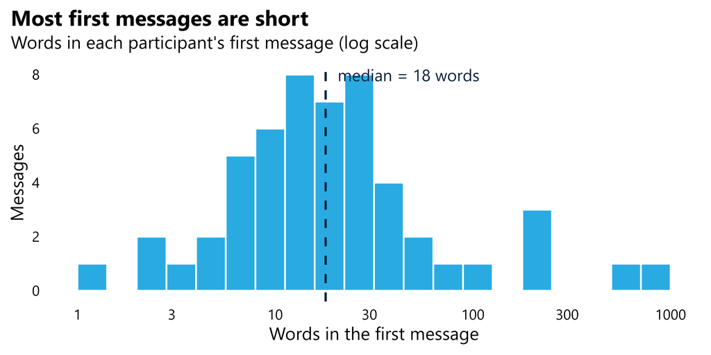

```r
p_len <- ggplot(first_msg, aes(n_words)) +
  geom_histogram(binwidth = 0.15, fill = project_colors["clay"], color = "white", boundary = 0) +
  scale_x_log10(breaks = c(1, 3, 10, 30, 100, 300, 1000)) +
  geom_vline(xintercept = median(first_msg$n_words), linewidth = 1.2, linetype = "dashed",
             color = project_colors["charcoal"]) +
  annotate("text", x = median(first_msg$n_words) * 1.15, y = Inf, vjust = 1.5, hjust = 0, size = 6.5,
           label = paste0("median = ", median(first_msg$n_words), " words"), color = project_colors["charcoal"]) +
  labs(title = "Most first messages are short",
       subtitle = "Words in each participant's first message (log scale)",
       x = "Words in the first message", y = "Messages")
p_len
```

```r
save_fig("first-message-length", p_len, width = 11, height = 5.5)
```

## 2. Three independent passes per codebook

Script: `scripts/07_build-codebook/07b_write_pass_prompts.py` fills in `prompts/topic_pass_prompt.md` and `prompts/request_pass_prompt.md` once for each pass.

Each of the 6 passes ran in a **separate, fresh LLM session**. It could see only its own prompt and its own shuffled file, so no pass saw another pass’s answers. The rules in the prompts:

- **Health topic:** code the *subject only*, not the kind of help wanted or who it is for. Give one primary topic and an optional secondary topic. Messages with no clear health subject get “NONE”.
- **Type of request:** code the *kind of help wanted*, not the subject. A message can have several types. There is **no code for replying to or following up on the AI**.
- Both: **no example categories** were given, so the codes come from the messages themselves. Each code needs a definition, signs, how it differs from its nearest code, 2–3 verbatim quotes, and at least 3 messages. We aimed for roughly 5–8 codes.

What each pass found:

```r
bind_rows(topic$pass_codes |> mutate(book = "Health topic"),
          request$pass_codes |> mutate(book = "Type of request")) |>
  arrange(book, pass, desc(n_chats)) |>
  mutate(group = paste0(book, ": pass ", pass)) |>
  select(group, name, n_chats, merged_into) |>
  gt(groupname_col = "group") |>
  cols_label(name = "Code named by the pass", n_chats = "Messages", merged_into = "Merged into") |>
  tab_options(table.font.size = px(16), row_group.font.weight = "bold")
```

| Code named by the pass | Messages | Merged into |
| --- | --- | --- |
| Health topic: pass 1 |  |  |
| Bones, joints and muscles | 10 | T1 |
| Stomach and digestion | 6 | T3 |
| Skin, hair and allergies | 6 | T4 |
| Diet, weight and fitness | 6 | T2 |
| Infections and acute illness | 5 | T5 |
| Diabetes and hormones | 5 | T6 |
| Sleep and fatigue | 4 | T7 |
| Eyes and vision | 3 | T8 |
| Headaches and nerve pain | 3 | T9 |
| Pregnancy and reproductive health | 3 | T10 |
| Health topic: pass 2 |  |  |
| Bones, joints and muscles | 10 | T1 |
| Diet, weight and fitness | 8 | T2 |
| Stomach and digestion | 6 | T3 |
| Skin and allergies | 6 | T4 |
| Hormones, diabetes and reproductive health | 6 | T6 |
| Mental health and sleep | 6 | T7 |
| Infections and acute illness | 5 | T5 |
| Eyes and vision | 4 | T8 |
| Headaches and nerve pain | 3 | T9 |
| Health topic: pass 3 |  |  |
| Bones, joints and muscles | 11 | T1 |
| Digestive and abdominal organs | 7 | T3 |
| Infections and acute illness | 7 | T5 |
| Nutrition, weight and fitness | 7 | T2 |
| Skin, hair and allergies | 6 | T4 |
| Hormones and metabolic conditions | 5 | T6 |
| Sleep and fatigue | 4 | T7 |
| Eyes and vision | 3 | T8 |
| Women's reproductive health | 3 | T10 |
| Type of request: pass 1 |  |  |
| Find the cause of symptoms | 13 | R1 |
| General health facts | 13 | R2 |
| Ways to relieve or manage | 8 | R3 |
| Deciding about medical care | 5 | R5 |
| Describe symptoms without a question | 5 | R4 |
| Check if normal or safe | 3 | dropped |
| Interpret results or numbers | 3 | dropped |
| Personal diet or supplement plan | 3 | R6 |
| Help with a writing task | 2 | dropped by analyst |
| Type of request: pass 2 |  |  |
| Asking what is causing symptoms | 14 | R1 |
| General health facts | 14 | R2 |
| Asking what to do for relief | 8 | R3 |
| Stating a symptom or result only | 7 | R4 |
| Advice on whether to act | 5 | R5 |
| Personal plan or recommendations | 3 | R6 |
| Help with a text task | 2 | dropped by analyst |
| Type of request: pass 3 |  |  |
| Possible cause of symptoms | 14 | R1 |
| General health facts | 14 | R2 |
| What to do for relief | 9 | R3 |
| Information shared without a question | 7 | R4 |
| Whether to seek medical care | 4 | R5 |
| Personal plan or product recommendations | 4 | R6 |

**Show the full pass prompts (pass 1 of each codebook)**

**Health topic**

````
You are a qualitative researcher drafting a codebook from real data. This is pass 1 of 3 independent passes. Work only from the file named below. Do not open any other file in the project, and do not look for or read the output of any other pass.

## The data

`C:\Users\DeniciaAragon\OneDrive - Healogix\Q4_3_Pulse\output\07_build-codebook\input\topic_pass_1_input.txt` holds 53 short texts. Each one is the **first message** that a survey participant wrote to an AI chatbot about a health question, for themselves or for someone else. The messages appear in a shuffled order (seed 7101).

- Each block starts with `=== CHAT <chat_id> ===` and ends with `=== END CHAT ===`.
- `[FIRST MESSAGE]:` is the participant's first message. **This is the only text you code.**
- In 2 blocks, a `[CONTEXT ONLY ...]` line shows AI text that came before the first message. Read it only to understand what the message is about. Never code it or quote it.
- Line breaks were lost in the survey export, so text may run together. Personal names were replaced with `[NAME]`.

Read the whole file before drafting. For example:
`C:\Users\DeniciaAragon\miniconda3\python.exe -c "print(open(r'C:\Users\DeniciaAragon\OneDrive - Healogix\Q4_3_Pulse\output\07_build-codebook\input\topic_pass_1_input.txt',encoding='utf-8').read())"`
If you use PowerShell, set `$env:PYTHONIOENCODING="utf-8"` first.

## What to find

Build a codebook of **health topics**: the health subject each first message asks about, such as a condition, a body system, or an area of health.

- Code the **subject only**. Do not code what kind of answer the person wanted, who the question is about, or how it was phrased. A separate codebook covers the type of request.
- No example categories are given on purpose. The topics should come from the messages themselves.
- Give every message **one primary topic**, the main subject. Add **one optional secondary topic** only if the message clearly also asks about a second subject.
- Topics should be broad enough to recur. Keep only topics that cover at least 3 different messages, counting primary and secondary. For 53 messages, roughly 5 to 8 topics is a sensible size. Do not force a number.
- If a message has no clear health subject, or its subject fits none of your topics, give it the primary topic `"NONE"` and explain why in `no_code_chats`.

For each topic, give:

1. `name`: a short, plain-language name of 1 to 5 words.
2. `definition`: 1 to 3 sentences. The first sentence must stand on its own as the definition. Say what is included and what is not.
3. `signs`: 2 to 5 concrete signs in the message, such as kinds of words, conditions, body parts or medicines.
4. `closest_other`: the name of your most similar topic, and `how_it_differs` in one or two sentences, including how to decide between them.
5. `examples`: 2 or 3 example quotes from **different chats**, each with its `chat_id`. Each quote must be copied **exactly, character for character**, from a `[FIRST MESSAGE]` line: one continuous stretch of 3 to 40 words, or the whole message if it is shorter. Do not fix spelling, punctuation or capitals, and do not join separate pieces with "...".

## Output

Write **only** valid JSON, in UTF-8, to `C:\Users\DeniciaAragon\OneDrive - Healogix\Q4_3_Pulse\output\07_build-codebook\passes\topic_pass_1_raw_output.json`, with this exact structure:

```json
{
  "codebook": "topic",
  "pass": 1,
  "seed": 7101,
  "n_messages_read": 53,
  "codes": [
    {
      "name": "...",
      "definition": "...",
      "signs": ["...", "..."],
      "closest_other": "...",
      "how_it_differs": "...",
      "examples": [{"chat_id": "...", "quote": "..."}]
    }
  ],
  "assignments": [{"chat_id": "...", "primary": "<topic name or NONE>", "secondary": "<topic name or null>"}],
  "no_code_chats": [{"chat_id": "...", "reason": "..."}],
  "notes": "Anything a researcher should know: borderline calls, topics seen in only 1-2 messages, any personal identifiers you noticed."
}
```

`assignments` must hold all 53 chats exactly once. Every `primary` and `secondary` must be one of your topic names, `"NONE"` (primary only), or `null` (secondary only).

Write the file with Python's `json.dump(..., ensure_ascii=False, indent=2)`, then load it again to confirm that it is valid. Then check that:

- every quote is found exactly in the input file, inside the credited chat's first message;
- every chat appears once in `assignments`;
- every topic covers at least 3 chats.

Fix anything that fails. Do not create any other files. Your final reply should be one short line confirming that the file was written, with the number of topics.
````

**Type of request**

````
You are a qualitative researcher drafting a codebook from real data. This is pass 1 of 3 independent passes. Work only from the file named below. Do not open any other file in the project, and do not look for or read the output of any other pass.

## The data

`C:\Users\DeniciaAragon\OneDrive - Healogix\Q4_3_Pulse\output\07_build-codebook\input\request_pass_1_input.txt` holds 53 short texts. Each one is the **first message** that a survey participant wrote to an AI chatbot about a health question, for themselves or for someone else. The messages appear in a shuffled order (seed 7201).

- Each block starts with `=== CHAT <chat_id> ===` and ends with `=== END CHAT ===`.
- `[FIRST MESSAGE]:` is the participant's first message. **This is the only text you code.**
- In 2 blocks, a `[CONTEXT ONLY ...]` line shows AI text that came before the first message. Read it only to understand the message. Never code it or quote it.
- Line breaks were lost in the survey export, so text may run together. Personal names were replaced with `[NAME]`.

Read the whole file before drafting. For example:
`C:\Users\DeniciaAragon\miniconda3\python.exe -c "print(open(r'C:\Users\DeniciaAragon\OneDrive - Healogix\Q4_3_Pulse\output\07_build-codebook\input\request_pass_1_input.txt',encoding='utf-8').read())"`
If you use PowerShell, set `$env:PYTHONIOENCODING="utf-8"` first.

## What to find

Build a codebook of **types of request**: what the participant wanted the AI to give them in this first message, that is, the kind of help or answer they were after.

- Code the **kind of help wanted**, not the health subject. The same type of request can be about any illness, symptom or medicine, and must not be split by subject. A separate codebook covers health topics.
- **Do not create a code for replying to, following up on, or reacting to the AI.** We are studying what people asked for at the start. If a message continues an earlier exchange, code what it asks for.
- No example categories are given on purpose. The types should come from the messages themselves.
- A message can show **more than one** type of request. Code every type that is clearly there.
- A type should recur: keep only types seen in at least 3 different messages. For 53 messages, roughly 5 to 8 types is a sensible size. Do not force a number.
- List any messages that fit none of your types, such as a greeting with no request, in `no_code_chats` with a reason.

For each type of request, give:

1. `name`: a short, plain-language name of 2 to 6 words.
2. `definition`: 1 to 3 sentences. The first sentence must stand on its own as the definition.
3. `signs`: 2 to 5 concrete signs in the message, such as typical phrasings or question forms.
4. `closest_other`: the name of your most similar type, and `how_it_differs` in one or two sentences, including how to decide between them.
5. `examples`: 2 or 3 example quotes from **different chats**, each with its `chat_id`. Each quote must be copied **exactly, character for character**, from a `[FIRST MESSAGE]` line: one continuous stretch of 3 to 40 words, or the whole message if it is shorter. Do not fix spelling, punctuation or capitals, and do not join separate pieces with "...".
6. `chat_ids`: every chat that shows this type. `n_chats` must equal the length of this list.

## Output

Write **only** valid JSON, in UTF-8, to `C:\Users\DeniciaAragon\OneDrive - Healogix\Q4_3_Pulse\output\07_build-codebook\passes\request_pass_1_raw_output.json`, with this exact structure:

```json
{
  "codebook": "request",
  "pass": 1,
  "seed": 7201,
  "n_messages_read": 53,
  "codes": [
    {
      "name": "...",
      "definition": "...",
      "signs": ["...", "..."],
      "closest_other": "...",
      "how_it_differs": "...",
      "examples": [{"chat_id": "...", "quote": "..."}],
      "chat_ids": ["...", "..."],
      "n_chats": 0
    }
  ],
  "no_code_chats": [{"chat_id": "...", "reason": "..."}],
  "notes": "Anything a researcher should know: borderline calls, types seen in only 1-2 messages, any personal identifiers you noticed."
}
```

Every one of the 53 chats must appear in at least one code's `chat_ids` or in `no_code_chats`, and not in both.

Write the file with Python's `json.dump(..., ensure_ascii=False, indent=2)`, then load it again to confirm that it is valid. Then check that:

- every quote is found exactly in the input file, inside the credited chat's first message;
- every `chat_id` exists;
- every chat is covered.

Fix anything that fails. Do not create any other files. Your final reply should be one short line confirming that the file was written, with the number of types.
````

## 3. Merging the passes

For each codebook, a 4th fresh session read only the three pass outputs and the first messages (`prompts/merge_prompt.md`). It matched codes **by meaning, not by name**, and kept a code only if **at least 2 of the 3 passes** found it. Codes found by just one pass are listed below. Any the merger thought worth a second look are flagged for you to decide on.

```r
dropped_all <- bind_rows(topic$dropped |> mutate(book = "Health topic"),
                         request$dropped |> mutate(book = "Type of request"))
if (nrow(dropped_all) > 0) {
  dropped_all |>
    mutate(worth_review = ifelse(worth_review %in% TRUE, "Yes", "")) |>
    select(book, dropped_by, pass, name, reason, worth_review) |>
    gt(groupname_col = "book") |>
    cols_label(dropped_by = "Dropped by", pass = "Pass", name = "Dropped code", reason = "Why",
               worth_review = "Worth your review?") |>
    tab_options(table.font.size = px(16), row_group.font.weight = "bold")
} else cat("No pass code was dropped.")
```

| Dropped by | Pass | Dropped code | Why | Worth your review? |
| --- | --- | --- | --- | --- |
| Type of request |  |  |  |  |
| merge (found in only 1 pass) | 1 | Check if normal or safe | Only pass 1 had this code (3 chats). Passes 2 and 3 coded the same messages as Ask what is causing symptoms (616f347d, 6144ea17) or as a medical-care/relief decision (69d51123). |  |
| merge (found in only 1 pass) | 1 | Interpret results or numbers | Only pass 1 had this code (3 chats). Passes 2 and 3 coded bare results as Information shared without a question; 5eec8774 (DEXA) was coded as relief in all passes. Interpreting one's own test results … | Yes |
| analyst | merged code | Help with a text task | After excluding the homework chat (69c41892) only 2 chats remained, below the 3-chat minimum. The researcher agreed it is too small, and judged that 66fd6acd (adding an article to a project) is not a … |  |

**How a message is counted.** Each pass placed messages under its own codes. For a merged code, a message **counts** if at least 2 of the 3 passes put it there. This majority vote means one pass’s odd call cannot add or remove a message. For topics, the **primary topic** is the one that at least 2 passes chose as primary. If the 3 passes chose 3 different primary topics, the message is marked “no majority”.

## 4. Changes made after the passes

Two kinds of change were made *after* the LLM passes. The passes were **not** rerun, because the codebooks are still drafts. Instead, the script `07c` recounts everything with the changes applied, and each change is written down so it can be checked.

### Exclusions

In step 05, 1 participant was **flagged `exclude = TRUE`**. Their paste was a homework assignment that happened to be about health (the AI summarised a CDC section on child development and wrote a class discussion post), not a personal health conversation. Their rows stay in the data, and the reason is recorded in `output/05_build-conversation-dataset/05_exclusions.csv`.

The 3 passes had already read this message, because they ran before it was excluded. So:

- it is **left out** of every count, every kappa, every chart and every codebook example in this report, which therefore covers **52** first messages;
- the pass input files are unchanged, so they still show exactly what the passes saw;
- the table below records what each pass did with it, which shows what changed when it was removed.

```r
excluded_chats |>
  mutate(codebook = books[codebook]) |>
  select(codebook, chat_id, pass, pass_codes, final_codes) |>
  gt(groupname_col = "codebook") |>
  cols_label(chat_id = "Chat", pass = "Pass", pass_codes = "Pass's code", final_codes = "Final code it maps to") |>
  tab_options(table.font.size = px(16), row_group.font.weight = "bold")
```

| Chat | Pass | Pass's code | Final code it maps to |
| --- | --- | --- | --- |
| Health topic |  |  |  |
| 69c41892 | 1 | NONE | (none) |
| 69c41892 | 2 | NONE | (none) |
| 69c41892 | 3 | NONE | (none) |
| Type of request |  |  |  |
| 69c41892 | 1 | Help with a writing task | dropped by analyst |
| 69c41892 | 2 | Help with a text task | dropped by analyst |
| 69c41892 | 3 | General health facts | R2 |

Removing it changed only one code’s count. **Help with a text task** fell from 3 chats to 2, below the 3-chat minimum. The topic codes did not change, because no majority of passes gave this message a topic.

### Your review decisions

After reading the draft, and later the pilot (step 08), you made the changes below. They are kept in a hand-made file, `07_codebook_revisions.csv`, and applied by `07c` after the majority vote. The `codebook_revisions` sheet of the workbook lists them with their final code IDs. Two rows are **analysis decisions** that change no labels: they record that topics are now a descriptive list (see “Context: health topics”). The next rows are the **pilot edits you approved (E6 to E9)**. They rewrite the *wording* of a code (its definition, signs or close-call rule), so that a new coder decides the pilot’s hard cases the way you intended. They do not change any message’s label; the full coding run will apply the new wording to every message. The next two rows **undo E8**, because you decided that emotion belongs in the later sentiment analysis, not in the request types. The next two rows **rename and clarify R3 and R6** around one simple question, *problem or goal?* R3, now **“How do I handle this problem, or is it safe?”**, starts from a symptom, injury or condition the person already has. R6, now **“Help me reach a health goal”**, starts from a goal such as weight, fitness or a routine, with nothing to fix. You made this change because “what should I do” and “recommendations” sounded too alike, and “personal” fits all health advice. The last six rows apply the **first real message rule** to 3 chats, once for each codebook (see “The first real message rule” below). **Kappa still describes the passes themselves**, so it is not changed by these decisions.

```r
revisions |>
  mutate(codebook = books[codebook],
         change = case_when(action == "drop_code" ~ paste0("Dropped the code \"", code_name, "\""),
                            action == "add_code"  ~ paste0("Added the code ", code, " \"", code_name, "\""),
                            action == "note" ~ paste0("Analysis decision: ", code_name,
                                                      ifelse(is.na(chat_id), "", paste0(" (chat ", chat_id, ")"))),
                            action %in% c("edit_wording", "revert_wording", "rename_clarify") ~
                              paste0(case_when(action == "revert_wording" ~ "Undid E8 in ",
                                               action == "rename_clarify" ~ "Renamed and clarified ",
                                               TRUE ~ "Reworded "), code, " \"",
                                     ifelse(is.na(new_code_name) | new_code_name == "", code_name,
                                            paste0(code_name, "\", now \"", new_code_name)), "\"",
                                     ifelse(is.na(chat_id) | chat_id == "", "",
                                            paste0(" (prompted by pilot chat ", chat_id, ")"))),
                            action == "substitute_unit" ~ paste0("First real message: coded chat ", chat_id, "'s ",
                                                                 "next message as ",
                                                                 ifelse(code_name == "NONE", "no topic (NONE)",
                                                                        paste0(code, " \"", code_name, "\""))),
                            TRUE ~ paste0("Coded chat ", chat_id, " as ", code, " \"", code_name, "\"",
                                          ifelse(role %in% "primary", " (primary topic)", "")))) |>
  select(codebook, change, reason) |>
  gt(groupname_col = "codebook") |>
  cols_label(change = "Change", reason = "Why") |>
  cols_width(change ~ px(330), reason ~ px(600)) |>
  tab_options(table.font.size = px(16), row_group.font.weight = "bold")
```

| Change | Why |
| --- | --- |
| Type of request |  |
| Dropped the code "Help with a text task" | After excluding the homework chat (69c41892) only 2 chats remained, below the 3-chat minimum. The researcher agreed it is too small, and judged that 66fd6acd (adding an article to a project) is not a … |
| Coded chat 66fd6acd as R6 "Personal plan or recommendations" | Was 'Help with a text task'. Asks the AI to use an article to improve the participant's own health and wellness project, i.e. their personal plan; pass 3 coded it this way. |
| Coded chat 6929d658 as R4 "Information shared without a question" | Was 'Help with a text task'. An email draft describing a personal struggle, with no question; closest remaining code is sharing information without a question. |
| Reworded R3 "Ask what to do for relief", now "Ask what to do or whether it is safe" (prompted by pilot chat 69d51123) | Pilot edit E7, approved. All 3 pilot coders coded a question about whether drinking is safe after surgery as this code, but its definition (relief) fitted only weakly. The definition now includes whet… |
| Reworded R6 "Personal plan or recommendations" (prompted by pilot chat 69f4ca1a) | Pilot edit E6, approved. The R6 sign about supplements and the R3/R6 close-call rule pointed in different directions. Personal plan is now for wellness or fitness GOALS only; a supplement asked for to… |
| Reworded R1 "Ask what is causing symptoms" (prompted by pilot chat 6a0206ae) | Pilot edit E8, approved. R1 and the 'what to do' code were written around physical symptoms, so the 3 pilot coders were unsure about the mental-health message. R1 now includes asking why they feel a c… |
| Reworded R5 "Whether to seek medical care" (prompted by pilot chat 69f441ce) | Pilot edit E9, approved. A small clarification: asking whether a recommended procedure is necessary belongs here. |
| Undid E8 in R1 "Ask what is causing symptoms" (prompted by pilot chat 6a0206ae) | Reverts pilot edit E8 (revision 11 and the coping part of revision 9). The researcher decided emotions are not coded as a type of request, because emotion will go into sentiment analysis later. R1 is … |
| Undid E8 in R3 "Ask what to do or whether it is safe" (prompted by pilot chat 6a0206ae) | Reverts the E8 part of revision 9: removes 'how to cope with stress or emotional strain' from the definition and signs. Emotion will go into sentiment analysis later. |
| Renamed and clarified R3 "Ask what to do or whether it is safe", now "How do I handle this problem, or is it safe?" | Rename and clarify, analyst decision. The researcher found 'what should I do' versus 'recommendations' confusing, and 'personal' applies to all health advice. R3 and R6 are now separated by problem ve… |
| Renamed and clarified R6 "Personal plan or recommendations", now "Help me reach a health goal" | Rename and clarify, analyst decision. The researcher found 'what should I do' versus 'recommendations' confusing, and 'personal' applies to all health advice. R3 and R6 are now separated by problem ve… |
| First real message: coded chat 6a24b2df's next message as R6 "Help me reach a health goal" | First REAL message rule (analyst decision): the first message was only a greeting and a joke, with no health content, so the participant's next message with a health statement or question is coded ins… |
| First real message: coded chat 6a9bb385's next message as R1 "Ask what is causing symptoms" | First REAL message rule (analyst decision): the first message was only a one-word reply ("nope"), with no health content, so the participant's next message with a health statement or question is coded… |
| First real message: coded chat 6ae359af's next message as R2 "General health facts" | First REAL message rule (analyst decision): the first message was only a greeting ("Hi meta"), with no health content, so the participant's next message with a health statement or question is coded in… |
| Health topic |  |
| Added the code T11 "Mental health and stress" | Requested by the researcher: messages about stress, anxiety or emotional struggles had no topic. Pass 2 had folded mental health into its sleep code; the merger suggested this topic. |
| Coded chat 6929d658 as T11 "Mental health and stress" (primary topic) | Personal struggle (not speaking to family) written for the participant's psychologist; the researcher placed it in mental health. |
| Coded chat 6a0206ae as T11 "Mental health and stress" (primary topic) | Asks to talk about stress and anxiety; the other uncoded message about stress/family struggles, which clearly fits the new topic. |
| Analysis decision: All topics (topics treated as descriptive list) | Topics treated as descriptive list. Type of request is the main analysis; health topic is context only: one primary topic per message, the secondary topic is left out of the main list, and topic agree… |
| Analysis decision: Kidney, liver and blood (chat 6a638cf5) | Pilot edit E2, handled simply: messages about the kidneys, liver or blood get a 'Kidney, liver and blood' line in the topic list (07_topic_list_groups.csv) instead of a new code. Only 6a638cf5 has no … |
| First real message: coded chat 6a24b2df's next message as T2 "Diet, weight and fitness" | First REAL message rule (analyst decision): the first message was only a greeting and a joke, with no health content, so the participant's next message with a health statement or question is coded ins… |
| First real message: coded chat 6a9bb385's next message as no topic (NONE) | First REAL message rule (analyst decision): the first message was only a one-word reply ("nope"), with no health content, so the participant's next message with a health statement or question is coded… |
| First real message: coded chat 6ae359af's next message as T3 "Stomach and digestion" | First REAL message rule (analyst decision): the first message was only a greeting ("Hi meta"), with no health content, so the participant's next message with a health statement or question is coded in… |

**Mental health and stress** now covers 2 chats. That is under the 3-chat minimum, but it is kept because you asked for it, and it is flagged as *small* in the tables. No other message without a topic clearly fits it. The rest are chest pain when running, a kidney ultrasound report, and a question about heart and chest scan results.

### The first real message rule

**The problem.** Some people opened their chat with just a greeting, a joke or a one-word reply, for example “Hi meta” or “nope”. Such a message tells us nothing about what they came to the AI for, so it ended up with no topic and no type of request. But the person’s *next* message was a real health question.

**The rule (your decision, 2026-11-05).** If the first message is **only** a greeting, a joke or a bare one-word reply with no health content, we code the person’s **next message that contains a health statement or question**. A real question is never replaced, however short it is (for example “is it safe to drink after surgery?” stays as it is). If a chat had no later health message, it would stay “No request”.

**How it is done, step by step.**

1. **A hand-made list.** The chats are listed in `07_first-message_substitutions.csv`, with the original turn, the turn used instead, and the reason. Nothing is decided by a hidden rule in the code.
2. **The data step (07a)** reads that list and adds a `coded_turn` and `coded_text` column to `first_messages.csv`. The original first message is kept in the `text` column. The AI message just before the new message is kept as **context only**, because without it a message like “what did these tests show?” makes no sense.
3. **The drafting passes were not rerun.** They read the original first messages, and their input files are left exactly as they saw them.
4. **Three fresh coders (07d).** Instead, 3 new messages were coded by 3 independent AI coders, each in its own session and its own shuffled order. They used the **frozen codebook**, with the same instructions as the pilot: a word-for-word quote, a confidence rating, and a note when a definition did not decide the case. A code counts when at least 2 of the 3 coders give it. All 3 coders agreed on every code, and 15 of 15 quotes were found word for word.
5. **Logged as revisions 17 to 22** (above), so the counts in this report include them.

**Please check these codes.** They are proposals until you confirm them.

```r
subs_msgs |>
  left_join(subs_codes |> select(chat_id, topic_primary, topic_primary_votes, request_codes, request_votes), by = "chat_id") |>
  mutate(topic_label = ifelse(topic_primary == "NONE", "No topic code (Other health subject: heart and chest scan results)",
                              paste0(topic_primary, " ", topic$codebook$name[match(topic_primary, topic$codebook$code)])),
         request_label = paste0(request_codes, " ", request$codebook$name[match(request_codes, request$codebook$code)]),
         codes = paste0("**Type of request:** ", request_label, " (", request_votes, ")<br>",
                        "**Topic:** ", topic_label, " (", topic_primary_votes, ")"),
         original = paste0("*", original_turn, ":* ", original_text),
         coded = paste0("*", coded_turn, ":* ", coded_text)) |>
  select(chat_id, original, coded, codes) |>
  gt() |>
  fmt_markdown(columns = c(original, coded, codes)) |>
  cols_label(chat_id = "Chat", original = "Original first message (not coded)",
             coded = "First real message (coded)", codes = "Codes from the 3 coders (votes)") |>
  cols_width(chat_id ~ px(100), original ~ px(250), coded ~ px(330), codes ~ px(420)) |>
  tab_source_note("Chat 6a9bb385: 'Convert to PDF' is button text pasted with the question, not part of it. All 3 coders gave R1 with low confidence: R1 is written around symptoms, and here the person asks what their own test results mean.") |>
  tab_options(table.font.size = px(17), data_row.padding = px(10))
```

| Chat | Original first message (not coded) | First real message (coded) | Codes from the 3 coders (votes) |
| --- | --- | --- | --- |
| 6a24b2df | *human_1:* hi we’re getting skinny LMFAOOOO HI 😭😭 | *human_2:* help me figure out a weight loss plan rn | **Type of request:** R6 Help me reach a health goal (R6 3/3) **Topic:** T2 Diet, weight and fitness (3/3) |
| 6a9bb385 | *human_1:* nope | *human_2:* Convert to PDF So, at a high level what did these tests show? | **Type of request:** R1 Ask what is causing symptoms (R1 3/3) **Topic:** No topic code (Other health subject: heart and chest scan results) (3/3) |
| 6ae359af | *human_1:* Hi meta | *human_2:* Tell me about stomach cramps | **Type of request:** R2 General health facts (R2 3/3) **Topic:** T3 Stomach and digestion (3/3) |

Chat 6a9bb385: 'Convert to PDF' is button text pasted with the question, not part of it. All 3 coders gave R1 with low confidence: R1 is written around symptoms, and here the person asks what their own test results mean.

## 5. Checking the example quotes

Script: `scripts/07_build-codebook/07c_check_and_build_codebook.py`

LLMs can tidy up or invent quotes. So a script checked every example quote from all passes and both merges, plus the 2 quotes you chose for the new mental-health topic (“analyst”). Each quote had to appear **word for word in the first message of the chat it is credited to**. Only spacing was allowed to differ. The quotes from the excluded chat were checked too, but they are not used as examples in the codebooks.

```r
quotes |>
  mutate(codebook = books[codebook]) |>
  group_by(codebook, source) |>
  summarise(quotes = n(), found_verbatim = sum(found_verbatim), .groups = "drop") |>
  mutate(result = ifelse(found_verbatim == quotes, "all found", "SOME NOT FOUND")) |>
  gt(groupname_col = "codebook") |>
  cols_label(source = "From", quotes = "Quotes", found_verbatim = "Found word for word", result = "") |>
  tab_options(table.font.size = px(16), row_group.font.weight = "bold")
```

| From | Quotes | Found word for word |  |
| --- | --- | --- | --- |
| Health topic |  |  |  |
| analyst | 2 | 2 | all found |
| merge | 29 | 29 | all found |
| pass 1 | 29 | 29 | all found |
| pass 2 | 27 | 27 | all found |
| pass 3 | 26 | 26 | all found |
| Type of request |  |  |  |
| merge | 21 | 21 | all found |
| pass 1 | 27 | 27 | all found |
| pass 2 | 20 | 20 | all found |
| pass 3 | 18 | 18 | all found |

```r
fails <- filter(quotes, !found_verbatim)
if (nrow(fails) > 0) {
  fails |> select(codebook, source, code, chat_id, quote) |> gt() |> tab_options(table.font.size = px(15))
} else cat("Every quote was found word for word in the participant's first message.")
```

```
## Every quote was found word for word in the participant's first message.
```

## 6. How well the passes agreed on the type of request

How to read the tables below:

- **Found in passes:** how many of the 3 passes came up with the code on their own.
- **Fleiss’ kappa:** whether the passes put the *same messages* under the code, after removing the agreement you would expect by chance. 1 is perfect, 0 is chance level, and above about 0.6 is usually called good.
- **All kappas use the 52 analysed messages** (the excluded chat is left out) and describe the passes *before* your review decisions. “Final count” includes those decisions. A code you added has no kappa (shown as a dash), because no pass found it.

```r
request$agreement |>
  select(code, name, n_passes_found, chats_pass1, chats_pass2, chats_pass3, n_chats,
         pct_chats_unanimous, fleiss_kappa) |>
  gt() |>
  cols_label(code = "", name = "Type of request", n_passes_found = "Found in passes",
             chats_pass1 = "Pass 1", chats_pass2 = "Pass 2", chats_pass3 = "Pass 3",
             n_chats = "Final count", pct_chats_unanimous = "All 3 agree",
             fleiss_kappa = "Fleiss' kappa") |>
  tab_spanner("Messages placed here by", columns = c(chats_pass1, chats_pass2, chats_pass3)) |>
  fmt_percent(pct_chats_unanimous, decimals = 0) |>
  tab_options(table.font.size = px(16))
```

|  | Type of request | Found in passes | Messages placed here by Pass 1 | Messages placed here by Pass 2 | Messages placed here by Pass 3 | Final count | All 3 agree | Fleiss' kappa |  |  |  |
| --- | --- | --- | --- | --- | --- | --- | --- | --- | --- | --- | --- |
| R1 | Ask what is causing symptoms | 3 | 13 | 14 | 14 |  |  |  | 15 | 98% | 0.97 |
| R2 | General health facts | 3 | 13 | 14 | 14 | 15 | 98% | 0.97 |  |  |  |
| R3 | How do I handle this problem, or is it safe? | 3 | 8 | 8 | 9 | 8 | 98% | 0.95 |  |  |  |
| R4 | Information shared without a question | 3 | 5 | 7 | 7 | 8 | 96% | 0.88 |  |  |  |
| R5 | Whether to seek medical care | 3 | 5 | 5 | 4 | 4 | 96% | 0.84 |  |  |  |
| R6 | Help me reach a health goal | 3 | 3 | 3 | 4 | 5 | 98% | 0.89 |  |  |  |

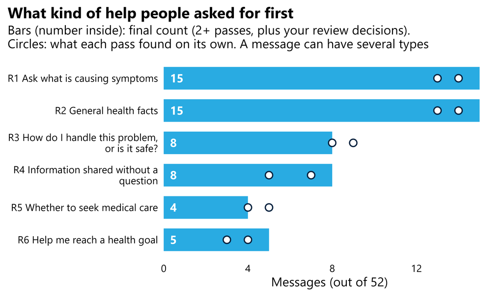

```r
req_plot <- request$agreement |>
  mutate(label = factor(paste0(code, " ", name), levels = rev(paste0(code, " ", name))))
req_pass <- req_plot |>
  select(label, starts_with("chats_pass")) |>
  pivot_longer(-label, names_to = "pass", values_to = "n") |>
  filter(n > 0)  # 0 means that pass did not have the code at all
p_req <- ggplot(req_plot, aes(n_chats, label)) +
  geom_col(fill = project_colors["clay"], width = 0.7) +
  geom_text(aes(x = 0.3, label = n_chats), hjust = 0, size = 6.5, fontface = "bold", color = "white") +
  geom_point(data = req_pass, aes(n, label), inherit.aes = FALSE, shape = 21, size = 4.5,
             fill = "white", color = project_colors["charcoal"], stroke = 1.4) +
  scale_x_continuous(expand = expansion(mult = c(0, 0.05))) +
  scale_y_discrete(labels = function(x) str_wrap(x, 34)) +
  labs(title = "What kind of help people asked for first",
       subtitle = "Bars (number inside): final count (2+ passes, plus your review decisions).\nCircles: what each pass found on its own. A message can have several types",
       x = paste0("Messages (out of ", n_analysed, ")"), y = NULL)
p_req
```

```r
save_fig("requests-per-code", p_req, width = 11, height = 6.5)
```

## 7. Draft codebook 1: health topic

This is the part to review. For each topic, the table shows:

- what it is and how to spot it;
- how it differs from its nearest neighbour;
- real examples, with the chat ID (the first 8 characters of the Prolific PID);
- how many of the 52 first messages have it as their primary topic.

The same content is in `07_Q4_3_draft_codebooks.xlsx` (sheet `topic_codebook`), where you can edit it.

```r
codebook_gt(topic$codebook, function(d) paste0(d$n_primary, " primary<br>", d$n_chats, " primary or secondary"))
```

Code

Definition

Signs in the message

How it differs

Examples (chat ID)

**T1. Bones, joints and muscles**  
9 primary  
10 primary or secondary  
(passes 1, 2, 3)

The message asks about pain, injury, or a condition of the bones, joints, muscles, back, or neck. Includes knee, back, neck, foot, and elbow pain, arthritis, osteoporosis, bone density and fracture risk, and bony lumps.

- names a joint, limb, back, or neck as the site of pain or injury  
  - mentions arthritis, osteoarthritis, osteoporosis, fractures, or bone density (DEXA) results  
  - pain after walking, exercise, lifting, or an injury  
  - asks what kind of joint or muscle injury something is

**vs. Headaches and nerve pain:** Bones, joints and muscles covers pain arising from bones, joints, muscles, and the spine. Headaches and nerve pain covers headaches and pain described as nerve-related (for example neuropathy). If the message names neuropathy or nerve pain, use Headaches and nerve pain even if the pain is in a limb; if it describes joint, back, or muscle pain without naming nerves, use Bones, joints and muscles. Chest and abdominal pain are not part of this code.

“what kind of knee injury does this sound like” (69fff128)  
“i developed a sharp pain in my neck that raidates to my shoulders suddenly” (5aeeb490)  
“symptoms of osteoarthrits” (663b8ae0)

**T2. Diet, weight and fitness**  
6 primary  
7 primary or secondary  
(passes 1, 2, 3)

The message asks about nutrition, body weight, exercise, or fitness goals. Includes healthy eating, protein and supplements for fitness, normal or ideal weight, fat loss, workouts, and weight-loss medicines such as GLP-1 drugs.

- asks about healthy foods, meal plans, or protein intake  
  - asks about normal or ideal weight, or losing fat or weight  
  - mentions workouts, exercise, or fitness goals  
  - mentions a GLP-1 or weight-loss medicine such as Zepbound

**vs. Diabetes and hormones:** Diet, weight and fitness is about lifestyle goals around eating, weight, and exercise. Diabetes and hormones is about a diagnosed or suspected hormone or metabolic condition (diabetes, A1c, cholesterol, hormone imbalance). If the message is about diet or supplements to treat a named condition, code the condition as primary and this code as an optional secondary.

“I want to discover affordable, healthy foods that will help me achieve my fitness and wellness goals.” (69a1ae3c)  
“What is the normal weight for a male who is 28 and five feet nine inches tall?” (6952e59d)  
“What impact (if any) has taking a GLP-1A medication had on your physical health?” (66c0f464)

**T3. Stomach and digestion**  
7 primary  
7 primary or secondary  
(passes 1, 2, 3)

The message asks about the stomach, bowel, anus, or other parts of the digestive tract. Includes stomach aches, belly or abdominal pain, gastritis, and anal or perianal problems such as fistulas.

- stomach ache, tummy ache, or belly pain  
  - names a digestive condition such as gastritis  
  - pain or symptoms when using the bathroom  
  - anal or perianal problems such as a fistula or perianal abscess

**vs. Infections and acute illness:** Stomach and digestion is about a problem located in the digestive tract. Infections and acute illness is about sudden, whole-body illness or infection in general (fever, chills, body aches). If the main subject is a gut or anal problem, use Stomach and digestion even if infection is mentioned (an infection may be a secondary topic); if the message is about feeling generally ill or about infections in general, use Infections and acute illness. Weight and diet goals belong to Diet, weight and fitness.

“I’ve been dealing with some bad stomach aches for the past few weeks.” (697cba85)  
“Could it be gastritis? Tell me what causes gastritis and how long it can last.” (6a10664c)  
“please list every disease where fistula-in-anu is a symptom” (6658d49a)

**T4. Skin, hair and allergies**  
6 primary  
6 primary or secondary  
(passes 1, 2, 3)

The message asks about the skin, scalp, or hair, or about allergic reactions. Includes eczema, hives, flaking or scabbing scalp, hair growth or loss, and allergies to foods or medicines such as antibiotics.

- names a skin condition such as eczema, hives, or a rash  
  - scalp flaking or scabbing, or hair growth or hair loss  
  - asks about an allergic reaction or allergy to a food or drug

**vs. Infections and acute illness:** Skin, hair and allergies covers surface skin and hair problems and allergic reactions. Infections and acute illness covers infections and short-term whole-body illness. An abscess or infection under the skin goes to Infections and acute illness (or the affected organ system); a rash, hives, or allergic reaction goes here. Hair changes while on a weight-loss drug go here, with Diet, weight and fitness as an optional secondary topic.

“What does it mean if I have eczema dry spots on my skin” (6acb95ac)  
“My scalp is flaking and scabbing” (672c1bfa)  
“Can an allergic reaction appear slowly” (6a21a961)

**T5. Infections and acute illness**  
4 primary  
5 primary or secondary  
(passes 1, 2, 3)

The message asks about an infection or a sudden, short-term illness. Includes flu-like or cold symptoms (fever, chills, body aches, congestion), named infectious diseases such as hand foot and mouth disease, and questions about whether something is an infection.

- sudden onset of feeling unwell with fever, chills, or body aches  
  - asks what illness they caught or whether it is the flu  
  - names an infectious disease or asks about infections in general  
  - asks about an abscess or whether something is infected

**vs. Stomach and digestion:** Infections and acute illness is about infection or sudden whole-body illness. If an infection is clearly located in one body system that has its own code (for example a perianal abscess), use that system’s code as primary and this code as secondary, or vice versa depending on which the message centres on. A headache on its own goes to Headaches and nerve pain; a headache that is one of several flu-like symptoms goes here. Tiredness that is part of a sudden flu-like illness goes here, not to Sleep and fatigue.

“Today I suddenly started feeling bad, fatigue, body aches, felt hot, later had the chills, nose is congested. What did I catch?” (664639e0)  
“What if hand foot and mouth isn’t treated” (6a637176)  
“can infections of some sort smell like onions” (66d8e4c1)

**T6. Diabetes and hormones**  
4 primary  
5 primary or secondary  
(passes 1, 2, 3)

The message asks about diabetes, blood sugar, or another hormone or metabolic condition. Includes A1c results, diabetes, hormone imbalance, seeing an endocrinologist, testosterone, and cholesterol.

- mentions diabetes, blood sugar, or an A1c value  
  - asks about hormone imbalance or an endocrinologist  
  - mentions testosterone or high cholesterol as a condition to manage

**vs. Pregnancy and reproductive health:** Diabetes and hormones covers hormone and metabolic conditions in general. Pregnancy and reproductive health covers pregnancy, labor, periods, and female reproductive organs. PCOS can fit either: if the message centres on periods, fertility, or other reproductive conditions (such as PMDD or endometriosis), use Pregnancy and reproductive health; if it centres on hormones, blood sugar, or cholesterol, use this code; use the other as secondary when both are present.

“72 yo woman with 6.0 a1c” (66ec5904)  
“Would an endocrinologist benefit me from learning why my hormones are our of whack?” (6abae4ea)  
“what diabetes” (6ad69d36)

**T7. Sleep and fatigue**  
3 primary  
4 primary or secondary  
(passes 1, 2, 3)

The message asks about sleep problems or ongoing tiredness. Includes poor or unrefreshing sleep, waking at night, sleep apnea, sleep loss, and fatigue, including sleep changes linked to a medicine.

- asks about sleep apnea or snoring  
  - waking during the night or trouble sleeping  
  - feeling tired even after enough sleep  
  - sleep changes after starting or changing a medicine

**vs. Infections and acute illness:** Sleep and fatigue covers sleep problems and tiredness as the main subject. If tiredness is one of several symptoms of a sudden flu-like illness, use Infections and acute illness. Stress, anxiety, and emotional struggles are not part of this code (see notes).

“I’ve been feeling unusually tired lately, even after getting a full night’s sleep.” (63e55f08)  
“What is sleep apnea? I think I may have it.” (5f491a49)  
“he’s been waking a lot in the night and he never used to do that.” (6144ea17)

**T8. Eyes and vision**  
3 primary  
3 primary or secondary  
(passes 1, 2, 3)

The message asks about the eyes or eyesight. Includes double vision, glasses, cataract surgery, and visits to eye doctors or retina specialists.

- mentions vision changes such as double vision  
  - mentions glasses, an eye doctor, or a retina specialist  
  - asks about cataracts or eye surgery

**vs. Headaches and nerve pain:** Eyes and vision is about the eyes themselves. Pain behind the eyes that comes with a headache or general illness goes to Headaches and nerve pain (or Infections and acute illness), not here.

“Sometimes I’m not seeing double with my glasses on but sometimes I am.” (616f347d)  
“My eye doctor is sending me to a retina specialist” (6a106089)  
“Percentage of people need to get 2nd eye’s cataract surgery after doing the first one.” (69f441ce)

**T9. Headaches and nerve pain**  
3 primary  
3 primary or secondary  
(passes 1, 2)

The message asks about headaches or nerve pain. Includes headaches with or without other symptoms such as vomiting, and neuropathy or other pain described as coming from nerves.

- says they have a headache or asks what to take for one  
  - headache with vomiting or pain behind the eyes  
  - mentions neuropathy or nerve pain

**vs. Bones, joints and muscles:** Headaches and nerve pain covers headaches and pain named as nerve-related. Pain in a joint, muscle, back, or neck that is not described as nerve pain goes to Bones, joints and muscles. A headache that is one of several flu-like symptoms (fever, chills, body aches) goes to Infections and acute illness.

“I have a headache, what should I take?” (69fd05bd)  
“I have had an headache and vomitting for 2 days and pain behind my eyes” (6a9f047c)  
“How to heal neuropathy pain in leg” (66d9e5be)

**T10. Pregnancy and reproductive health**  
2 primary  
3 primary or secondary  
(passes 1, 3)

The message asks about pregnancy, labor, menstruation, or the female reproductive organs. Includes labor and induction, periods, endometriosis, PCOS, and PMDD.

- mentions pregnancy, labor, or induction  
  - mentions periods or menstrual symptoms  
  - names a reproductive condition such as endometriosis, PCOS, or PMDD

**vs. Diabetes and hormones:** Pregnancy and reproductive health covers pregnancy and the female reproductive system. Diabetes and hormones covers hormone and metabolic conditions not tied to reproduction (diabetes, A1c, cholesterol, general hormone imbalance). When a message lists both kinds of conditions, code the one it centres on as primary and the other as secondary.

“Should you be drinking 3 weeks after endometriosis surgery and about to have your period?” (69d51123)  
“I want to deal with my pcos, anemia, pmdd, and high cholesterol” (69f4ca1a)

**T11. Mental health and stress**  
2 primary  
2 primary or secondary  
(added by the analyst)  
**Small: under 3 chats**

The message is about the participant’s mental or emotional wellbeing: stress, anxiety, low mood, or emotional struggles in relationships or family life, rather than a physical symptom.

- Words such as stressed, anxious, struggling, overwhelmed  
  - Describes feelings or relationships rather than a body part or physical symptom  
  - Asks how to cope or feel better emotionally

**vs. Sleep and fatigue:** Sleep and fatigue is about sleep problems or physical tiredness; Mental health and stress is about emotional strain, stress or anxiety, even if tiredness is mentioned.

“I just went a whole week without saying anything to my family.” (6929d658)  
“I would like to talk about what’s stressing me out and why I’m anxious and what I can do to give myself a better quality of life.” (6a0206ae)

### First messages with no topic

```r
if (nrow(topic$no_code) > 0) {
  topic$no_code |>
    mutate(text = str_trunc(text, 300),
           why = coalesce(na_if(pass1_reason, ""), na_if(pass2_reason, ""), na_if(pass3_reason, ""), "")) |>
    select(chat_id, primary_topic, text, why) |>
    gt() |>
    cols_label(chat_id = "Chat", primary_topic = "Result", text = "First message (first 300 characters)",
               why = "A pass's reason") |>
    tab_options(table.font.size = px(16))
} else cat("Every first message has a primary topic.")
```

| Chat | Result | First message (first 300 characters) | A pass's reason |
| --- | --- | --- | --- |
| 671a8337 | NONE | CHEST PAIN WHEN RUNNING | Chest pain when running; heart/chest topics appear only in this message. |
| 6a638cf5 | NONE | FINDINGS: The right kidney is measured at 12.2 x 6.1 x 5.0 cm. The renal cortex is normal in thickness and normal in echogenicity. No hydronephrosis is seen. No dilated ureter is seen. 0.6 cm shadowin… | Pasted kidney/bladder ultrasound report (kidney stone, kidney cysts, liver echogenicity); kidney and urinary topics appear in only this message. |
| 6a9bb385 | NONE | nope | Single word 'nope' replying to earlier conversation; no health subject in the message. |

## 8. Draft codebook 2: type of request

The same layout. A message can have more than one type, so the counts add up to more than 52. The editable copy is the `request_codebook` sheet.

```r
codebook_gt(request$codebook, function(d) paste0(d$n_chats, " messages"))
```

Code

Definition

Signs in the message

How it differs

Examples (chat ID)

**R1. Ask what is causing symptoms**  
15 messages  
(passes 1, 2, 3)

The participant describes their own or someone else’s symptoms or health change and asks what could be causing it or what it means. The help wanted is an explanation or likely diagnosis for a specific personal situation.

- “What could be causing this?” or “what could be the problem”  
  - “What did I catch?” or “what kind of injury does this sound like”  
  - “Could it be X or Y?” offering candidate causes  
  - “Is that typical” or “Does that make sense?” about a described personal symptom  
  - “How do I know if I have X”

**vs. General health facts:** This code needs a personal case described in the message and a question about what is behind it. If the question is about a condition, medicine or procedure in general, use General health facts. A message can carry both (e.g. “Could it be gastritis? Tell me what causes gastritis”); code both.

“Sometimes I wake up feeling like I haven’t rested at all. What could be causing this?” (63e55f08)  
“nose is congested. What did I catch?” (664639e0)  
“what kind of knee injury does this sound like” (69fff128)

**R2. General health facts**  
15 messages  
(passes 1, 2, 3)

The participant asks for general information about a condition, symptom, test, procedure, medicine or health measure, not tied to explaining their own case. This includes definitions, symptom lists, causes, norms, statistics and likely outcomes.

- “What is X?” or “symptoms of X”  
  - “Can X …?” or “Does X …?” general yes-or-no fact questions  
  - “List every …” or “Percentage of people …”  
  - “What if X isn’t treated” or “what causes X and how long can it last”  
  - “What will they do” at a test or appointment

**vs. Ask what is causing symptoms:** General health facts asks how health works in general; Ask what is causing symptoms asks to explain a specific personal case. Decide by whether the question is about the person’s own described symptoms (code R1) or about a named condition or topic in general (code R2); code both if both are asked.

“Can an allergic reaction appear slowly” (6a21a961)  
“please list every disease where fistula-in-anu is a symptom” (6658d49a)  
“What is the normal weight for a male who is 28 and five feet nine inches tall?” (6952e59d)

**R3. How do I handle this problem, or is it safe?**  
8 messages  
(passes 1, 2, 3)

The participant starts from a health problem they (or someone they care for) already have: a current symptom, injury, condition or recovery. They ask how to treat, relieve or manage it, or whether something (an everyday activity, food, drink, medicine or product) is safe while they have it. The help wanted is practical advice for dealing with that problem.

- “What should I take?”  
  - “What can I do to help/alleviate…”  
  - “How to heal X”  
  - “what do I do?” after describing a problem  
  - “Would switching … help” about adjusting a current treatment  
  - “Should I/you be [doing an everyday activity]” or “is it safe to …” during a current problem or recovery  
  - Asks for a supplement or product to treat named conditions

**vs. Whether to seek medical care:** Problem vs. goal: this code starts from a problem the person already has and asks how to handle it or whether something is safe. If there is no problem to fix and the person wants to reach a goal (weight, fitness, eating, a routine), use Help me reach a health goal. A supplement or product asked for to treat NAMED conditions is this code; add Help me reach a health goal only if a separate goal is also stated. If the only choice being weighed is whether or when to see, call or use a professional or procedure, use Whether to seek medical care.

“I have a headache, what should I take?” (69fd05bd)  
“what can i do to alleviate knee pain and get back to normal?” (69fb8bf7)  
“How to heal neuropathy pain in leg” (66d9e5be)

**R4. Information shared without a question**  
8 messages  
(passes 1, 2, 3)

The participant states a symptom, health detail or test result with no explicit question or request, leaving the AI to infer what help is wanted (usually an assessment). This includes bare symptom phrases and pasted reports or lab values.

- A short symptom phrase with no question, e.g. “CHEST PAIN WHEN RUNNING”  
  - A statement about someone’s symptom or a noticed change, with no request  
  - Age plus a test value, e.g. “72 yo woman with 6.0 a1c”  
  - A pasted lab or imaging report with no request

**vs. Ask what is causing symptoms:** Use this code only when no question or request is stated. If the message explicitly asks what is causing it, what it is, or what to do, code that request instead.

“CHEST PAIN WHEN RUNNING” (671a8337)  
“72 yo woman with 6.0 a1c” (66ec5904)  
“Husband’s low back started hurting yesterday” (69600cc8)

**R5. Whether to seek medical care**  
4 messages  
(passes 1, 2, 3)

The participant asks whether they should see a doctor or specialist, have a procedure, or contact their care team, or when to do so. This includes asking whether a recommended procedure is necessary for them. The help wanted is a judgement on a specific decision about using professional care.

- “Should I see a medical specialist … or try to wait it out?”  
  - “Would an endocrinologist benefit me”  
  - “Is it a must?” about a procedure  
  - Checking when they can or should call the care team

**vs. How do I handle this problem, or is it safe?:** This code is about a named decision to use (or not use) professional care, or its timing. If the person asks for self-care, medicine or habit steps, use How do I handle this problem, or is it safe?. A general question about what happens at an appointment is General health facts.

“Should I see a medical specialist about this or try to wait it out?” (697cba85)  
“Would an endocrinologist benefit me from learning why my hormones are our of whack?” (6abae4ea)  
“Percentage of people need to get 2nd eye’s cataract surgery after doing the first one. Is it a must?” (69f441ce)

**R6. Help me reach a health goal**  
5 messages  
(passes 1, 2, 3)

The participant starts from a health goal, not a problem to fix: for example losing weight, building muscle or fitness, eating better or keeping a healthy routine. They ask for a plan, routine or suggestions (foods, meals, supplements, exercises) to reach it. The help wanted is a plan towards the goal.

- States a goal such as fat loss, muscle gain, toning or eating healthier  
  - Lists current diet, supplements, weight or budget as background for the goal  
  - “Please recommend specific foods” or “suggest … ideas”  
  - Asks for a supplement, food or product to meet a GOAL, with no named condition to treat

**vs. How do I handle this problem, or is it safe?:** Problem vs. goal: this code starts from a goal, with no symptom, injury or condition to fix. If the person describes a current problem or recovery and wants to treat, manage or stay safe with it, use How do I handle this problem, or is it safe?. A supplement or product asked for to treat NAMED conditions is that code; code this one as well only if a separate goal is also stated.

“I want to discover affordable, healthy foods that will help me achieve my fitness and wellness goals.” (69a1ae3c)  
“fat loss, muscle gain and increasing testosterone are the main objectives.” (69fcf529)

### First messages with no type of request

```r
if (nrow(request$no_code) > 0) {
  request$no_code |>
    mutate(text = str_trunc(text, 300),
           why = coalesce(na_if(pass1_reason, ""), na_if(pass2_reason, ""), na_if(pass3_reason, ""), "")) |>
    select(chat_id, text, why) |>
    gt() |>
    cols_label(chat_id = "Chat", text = "First message (first 300 characters)", why = "A pass's reason") |>
    tab_options(table.font.size = px(16))
} else cat("Every first message has at least one type of request.")
```

[output not shown]

## 9. What happens next

The codebooks are now final. The *counts* in this report are still the draft counts. Where things stand:

1. **Review and edit:** done. Your decisions are in section 4.
2. **Pilot:** done (step 08). Three fresh coders applied the codebooks to 12 messages, and 9 wording edits were proposed. After the pilot you decided that **type of request is the main analysis** and topics are a descriptive list. That makes the topic edits E1, E3, E4 and E5 unnecessary. E2, the kidney/liver/blood messages, is handled by the *Other health subject* line. You **approved the request edits E6, E7 and E9**, and they are applied (revisions 9 to 12). E8 was applied and then **reverted** (revisions 13 and 14): emotion will go into the sentiment analysis later. You then **renamed and clarified R3 and R6** around problem vs. goal (revisions 15 and 16), and added the **first real message rule** (revisions 17 to 22).
3. **Freeze:** done (step 09, `scripts/09_freeze-codebook/09_freeze_codebook.py`). The final wording is saved in `output/09_freeze-codebook/frozen_2026-11-05_v4/` as read-only files with a fingerprint (SHA-256 hash) of each. “Frozen” means the wording no longer changes, so every message is coded with exactly the same text. Any later change needs a new freeze, which is what happened here three times: version 1 (`frozen_2026-11-05/`) still had E8, version 2 (`frozen_2026-11-05_v2/`) had the old R3 and R6 names, and version 3 (`frozen_2026-11-05_v3/`) did not yet have the first real message rule. Version 4 has the same code definitions as version 3, plus that rule in its unit of analysis. The older versions are kept for the record and marked with a `SUPERSEDED.txt` note.
4. **Next: code every first message 3 times** with the frozen codebooks, quoting the evidence, and keep each code that at least 2 of the 3 runs give. This waits for your go-ahead. Under the new wording, a few draft labels will probably change. For example, the pilot coders gave the “is it safe to drink after surgery” message (69d51123) and the supplement-for-named-conditions message (69f4ca1a) the “how do I handle this problem, or is it safe?” type (R3).
5. **Hand-coding.** You will hand-code all messages, and we will compare your codes with the LLM’s.

`first_message_codes.csv` already lists each message with its draft primary topic, secondary topic and types of request. It is a preview only, not final coding.

**Limits to keep in mind**

- **Small sample.** There are 52 first messages. A code seen in 2–5 messages rests on very few people.
- **Pasted past chats.** People chose what to paste. Some pastes may not start at the true first message of the conversation; in 2 of them, AI text comes first.
- **Lost line breaks.** The export removed line breaks, so long first messages run together.

## Files written

All in `output/07_build-codebook/`:

- **`input/`**:
  - `first_messages.csv` (the 53 first messages, plus any AI context; the `exclude` column marks the excluded chat; `coded_turn` and `coded_text` give the message that is actually coded)
  - `substitute_messages.csv` (the 3 first real messages used instead of a greeting or one-word reply)
  - `topic_pass_N_input.txt` and `request_pass_N_input.txt` (the shuffled file each pass read)
  - `pass_orders.csv` (order and seed per pass)
  - `redaction_log.csv`
  - `settings.json`
- **`passes/`**: `<codebook>_pass_N_prompt.md` (the exact prompt) and `<codebook>_pass_N_raw_output.json` (raw LLM output)
- **`merge/`**: `<codebook>_merge_prompt.md` and `<codebook>_merge_raw_output.json`
- **`substitutes/`** (first real message rule, script `07d_code_substitute_messages.py`): `codebook_for_coders.md`, `coder_N_input.txt`, `coder_N_prompt.md` and `coder_N_output.json` (raw output of each of the 3 coders), `substitute_all_coders.csv`, `substitute_codes.csv` (the majority codes) and `substitute_quote_check.csv`
- **Results:**
  - `07_Q4_3_draft_codebooks.xlsx`, with sheets main_request_types and topic_list (the main results), topic_codebook, request_codebook, first_message_codes, overall_agreement, per-codebook agreement, no-code, dropped and pass codes, quote_check, and about
  - `main_request_types.csv` (% of first messages per type of request) and `topic_list.csv` (one primary topic per message)
  - the same tables as CSVs
  - `figures/`
  - this report
- **Exclusions and review decisions:**
  - `07_codebook_revisions.csv` (hand-made list of your review decisions; edit it to change them)
  - `07_topic_list_groups.csv` (hand-made: how the messages with no topic are listed)
  - `07_first-message_substitutions.csv` (hand-made: the chats where the first real message is coded, and why)
  - `codebook_revisions_applied.csv` and `excluded_chats.csv` (also sheets in the workbook)
- **`old_before-substitution/`**: the outputs and report from before the first real message rule.
- **`old_before-E8-revert/`**: the outputs and report from before E8 was reverted.
- **`old_before-R3-R6-rename/`**: the outputs and report from before R3 and R6 were renamed.
- **`old_before-pilot-edits/`**: the outputs and report from before pilot edits E6 to E9 were applied.
- **`old_before-restructure/`**: the outputs and report from before type of request became the main analysis.
- **`old_before-exclusion/`**: the workbook as it was before the exclusion and your review decisions.
- **`old_all-messages/`**: the earlier all-messages draft. Its inputs and raw JSON contain names, so **don’t share them**.

## Appendix: agreement on health topics

Health topics are now a descriptive list, so their agreement numbers are kept here for the record rather than in the main text. They use the same measures as section 6:

For topics there is also one overall kappa for the **primary topic**, where each pass picks one topic per message:

- kappa = 0.81;
- all 3 passes chose the same primary topic for 75% of messages;
- at least 2 agreed for 100%.

```r
topic$agreement |>
  select(code, name, n_passes_found, primary_pass1, primary_pass2, primary_pass3, n_primary, n_chats, fleiss_kappa) |>
  gt() |>
  cols_label(code = "", name = "Topic", n_passes_found = "Found in passes",
             primary_pass1 = "Pass 1", primary_pass2 = "Pass 2", primary_pass3 = "Pass 3",
             n_primary = "Final count: primary", n_chats = "Final count: primary or secondary",
             fleiss_kappa = "Fleiss' kappa") |>
  tab_spanner("Primary topic in", columns = c(primary_pass1, primary_pass2, primary_pass3)) |>
  sub_missing(missing_text = "—") |>
  tab_options(table.font.size = px(16))
```

|  | Topic | Found in passes | Primary topic in Pass 1 | Primary topic in Pass 2 | Primary topic in Pass 3 | Final count: primary | Final count: primary or secondary | Fleiss' kappa |  |  |  |
| --- | --- | --- | --- | --- | --- | --- | --- | --- | --- | --- | --- |
| T1 | Bones, joints and muscles | 3 | 9 | 10 | 10 |  |  |  | 9 | 10 | 0.96 |
| T2 | Diet, weight and fitness | 3 | 5 | 7 | 5 | 6 | 7 | 0.89 |  |  |  |
| T3 | Stomach and digestion | 3 | 5 | 6 | 7 | 7 | 7 | 0.94 |  |  |  |
| T4 | Skin, hair and allergies | 3 | 6 | 5 | 6 | 6 | 6 | 1.00 |  |  |  |
| T5 | Infections and acute illness | 3 | 5 | 3 | 6 | 4 | 5 | 0.87 |  |  |  |
| T6 | Diabetes and hormones | 3 | 4 | 6 | 4 | 4 | 5 | 0.79 |  |  |  |
| T7 | Sleep and fatigue | 3 | 3 | 5 | 4 | 3 | 4 | 0.84 |  |  |  |
| T8 | Eyes and vision | 3 | 3 | 3 | 3 | 3 | 3 | 0.89 |  |  |  |
| T9 | Headaches and nerve pain | 2 | 3 | 3 | 0 | 3 | 3 | 0.48 |  |  |  |
| T10 | Pregnancy and reproductive health | 2 | 2 | 0 | 2 | 2 | 3 | 0.48 |  |  |  |
| T11 | Mental health and stress | 0 | 0 | 0 | 0 | 2 | 2 | — |  |  |  |

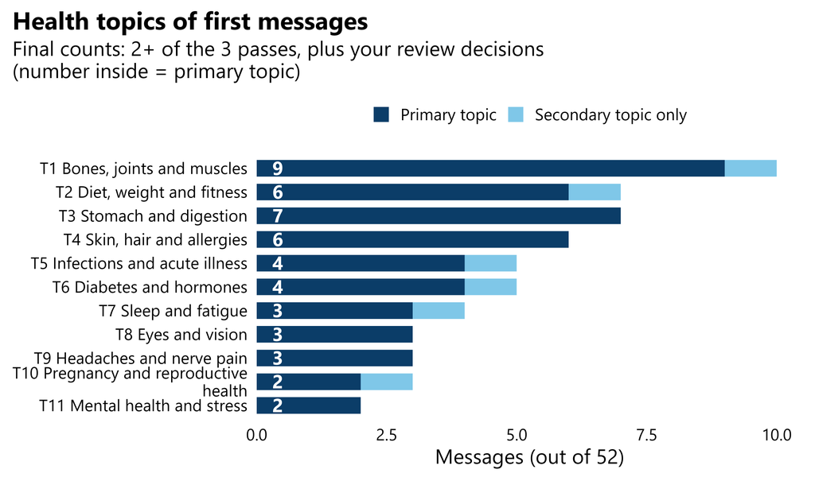

```r
topic_plot <- topic$agreement |>
  mutate(label = factor(paste0(code, " ", name), levels = rev(paste0(code, " ", name))),
         `Primary topic` = n_primary, `Secondary topic only` = n_chats - n_primary) |>
  pivot_longer(c(`Primary topic`, `Secondary topic only`), names_to = "type", values_to = "n") |>
  mutate(type = factor(type, levels = c("Secondary topic only", "Primary topic")))
p_topic <- ggplot(topic_plot, aes(n, label, fill = type)) +
  geom_col(width = 0.7) +
  geom_text(data = filter(topic_plot, type == "Primary topic", n > 0), aes(x = 0.3, label = n),
            hjust = 0, size = 6.5, fontface = "bold", color = "white") +
  scale_fill_manual(values = c(`Primary topic` = unname(project_colors["teal"]),
                               `Secondary topic only` = unname(project_colors["ochre"])),
                    breaks = c("Primary topic", "Secondary topic only")) +
  scale_x_continuous(expand = expansion(mult = c(0, 0.05))) +
  scale_y_discrete(labels = function(x) str_wrap(x, 34)) +
  labs(title = "Health topics of first messages",
       subtitle = "Final counts: 2+ of the 3 passes, plus your review decisions\n(number inside = primary topic)",
       x = paste0("Messages (out of ", n_analysed, ")"), y = NULL, fill = NULL) +
  theme(legend.position = "top")
p_topic
```

```r
save_fig("topics-per-code", p_topic, width = 11, height = 6.5)
```